# Capstone Statistical Analysis Report

J Slaga

5/22/2019

### Preliminary Exploration

After initial cleanup of the data - removing unneeded variables, eliminating canceled and diverted flights, and subsetting the data to just the top ten airports - I began the initial exploration of the data set. I started by running some quick tallies of delayed flights by day of the week, month, and by airline.

```
## # A tibble: 7 x 3
##   DAY_OF_WEEK    n.x    n.y
##   <fct>        <int>  <int>
## 1 Thursday    261921 629340
## 2 Monday      258082 629418
## 3 Friday      254644 624722
## 4 Wednesday   242490 632395
## 5 Sunday      238675 600154
## 6 Tuesday     238630 620034
## 7 Saturday    186748 507979
```

```
## # A tibble: 11 x 3
##    MonthName    n.x    n.y
##    <fct>      <int>  <int>
##  1 June      183473 399975
##  2 July      179508 416908
##  3 March     164011 397844
##  4 August    162741 408636
##  5 December  160673 383085
##  6 May       152551 398084
##  7 January   147820 369127
##  8 February  145202 329563
##  9 April     142879 388937
## 10 November  129564 376550
## 11 September 112768 375333
```

```
## # A tibble: 14 x 3
##    AIRLINE    n.x    n.y
##    <fct>    <int>  <int>
##  1 WN      468998 984910
##  2 DL      232372 674291
##  3 UA      229063 439696
##  4 AA      211276 594389
##  5 OO      110702 340365
##  6 EV       98462 299725
##  7 B6       77763 195456
##  8 US       59501 183169
##  9 MQ       57426 151804
## 10 NK       44890  95706
## 11 AS       30594 117456
## 12 F9       29889  74638
## 13 VX       21250  55573
## 14 HA        9004  36864
```

Thursday, Monday, and Friday have the most delays and Saturday the least. This is in line with what one would expect - more delays on the heavily traveled days and fewer on the least traveled day. Similarly, high travel / popular vacation months - the summer months and March and December - have a higher number of delays. (Note: October data is missing.) Grouped by airline, the number of delays falls almost perfectly in line with the number of flights. Noteably, Southwest Airlines (WN) has more than double the late flights of the next highest airline, Delta (DL).

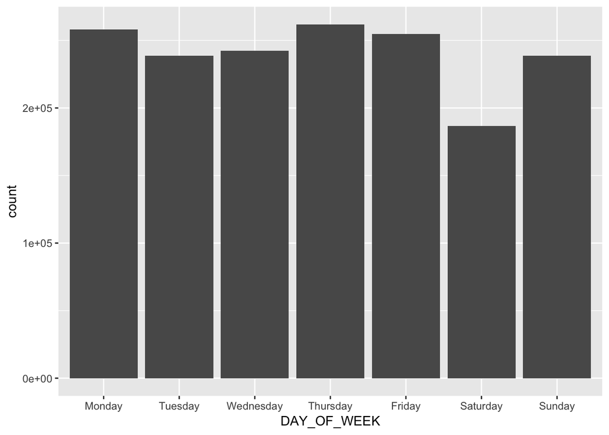

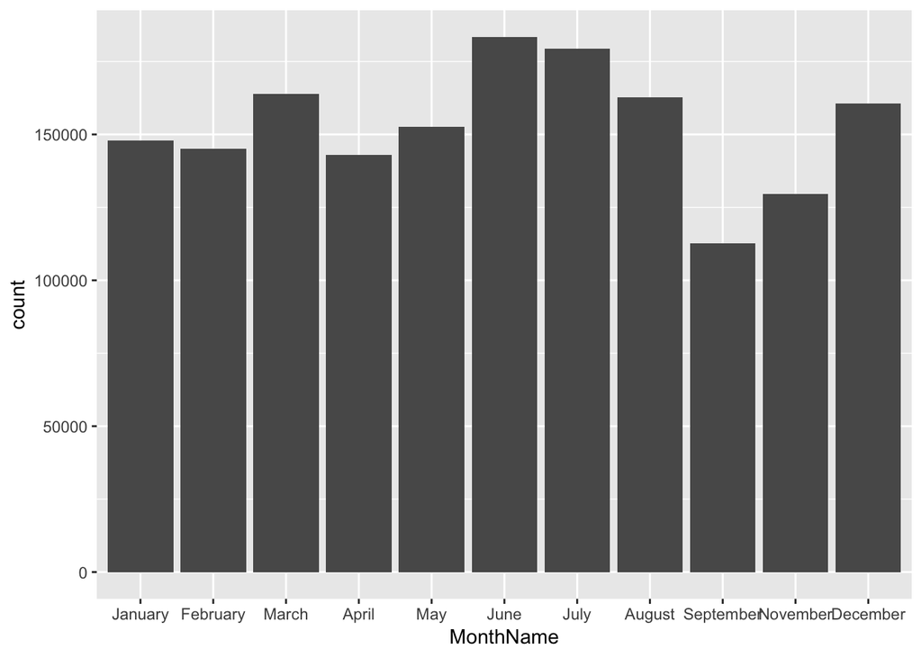

#### Distribution Of Delay Times

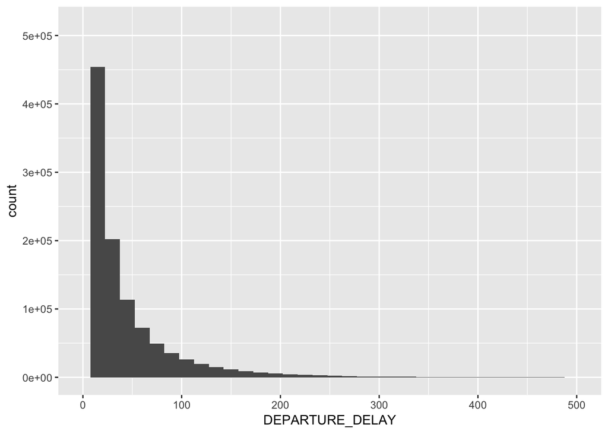

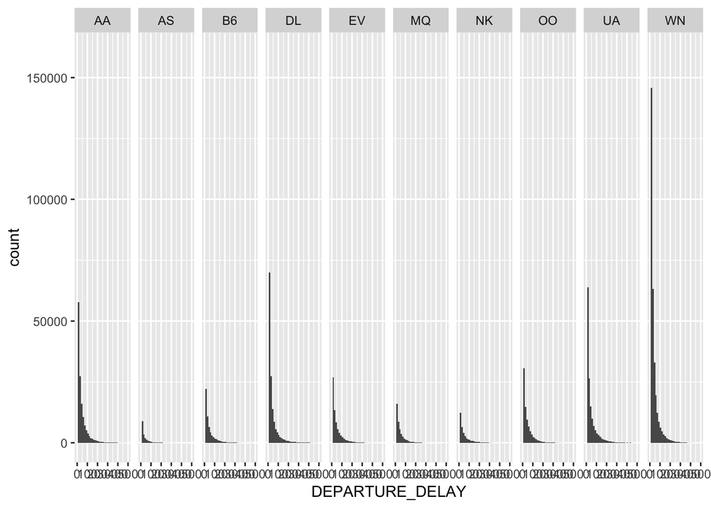

While Southwest has the most delayed flights of all the airlines, a large proportion of the delays are less than 30 minutes, and its longest delay is the least of all its competitors. In contrast, American Airlines (AA) has less than half of the late flights of Southwest, but has by far the longest delays of all the airlines. But what really stands out is that 75% of delays for each airline are less than 60 minutes.

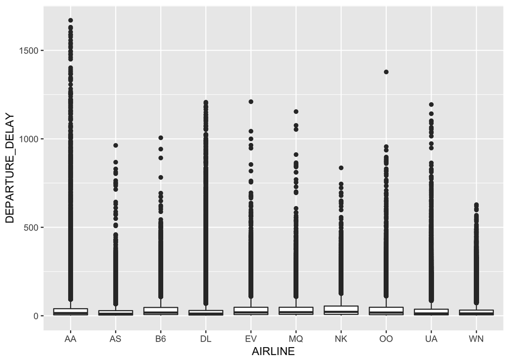

#### Short vs. Extreme Delays

I further examined flights with short delays (less than one hour) and extreme delays (over ten hours).

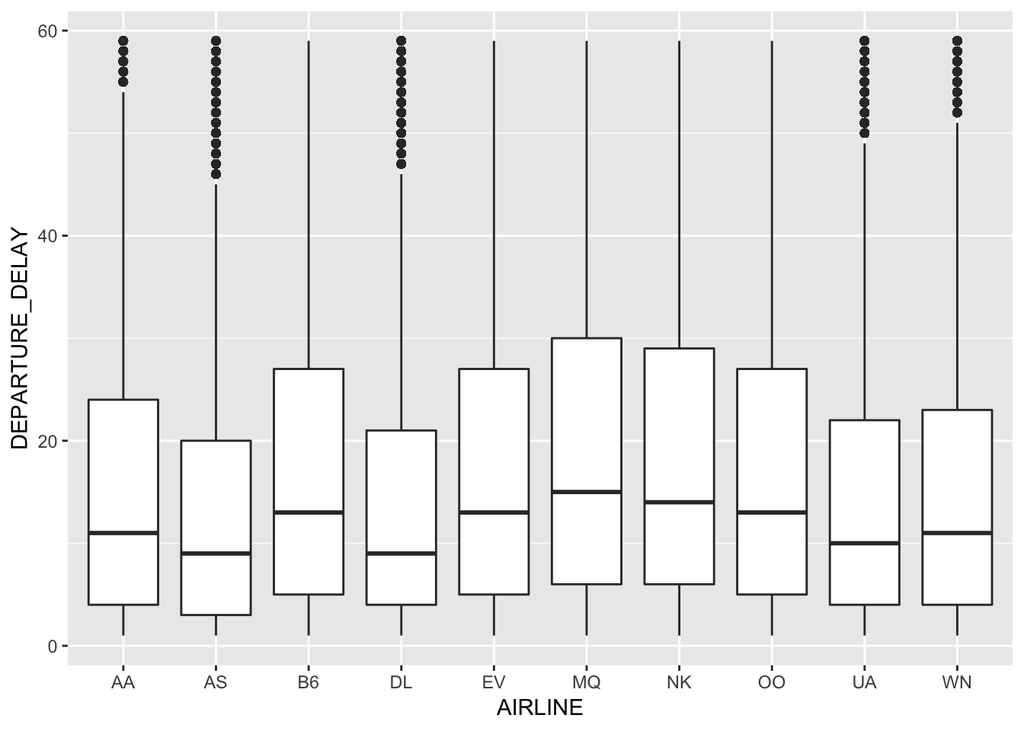

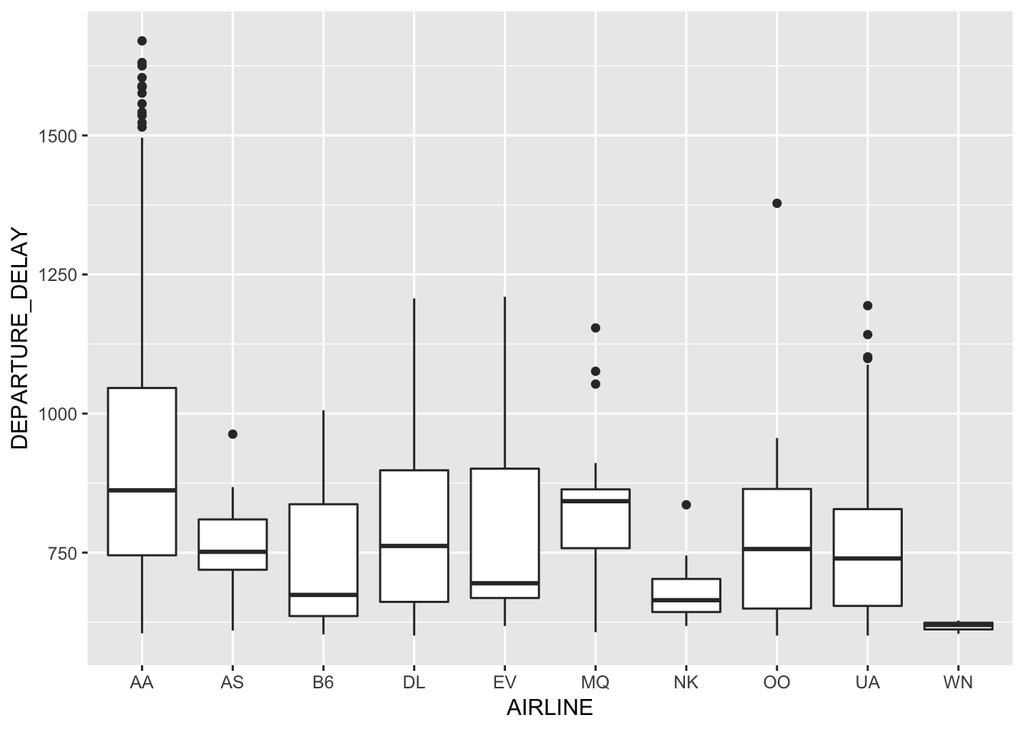

For delays less than one hour, all the airlines show similar distributions - their medians around 10 - 15 minutes and 75% of the delays for each airline falling below 30 minutes. Contrast this with the boxplot for the extreme delays where far more variance can be observed between the airlines. Again we can note that while Southwest has by far the largest number of delayed flights, it has very few extreme delays. In comparison, American Airlines (having half the total number of delayed flights of Southwest) has by far, the longest delays of all the airlines.

#### Weather Delays

One would expect weather delays to occur most often during certain times of year. I examined by month the amount of time departures were delayed for each airline.

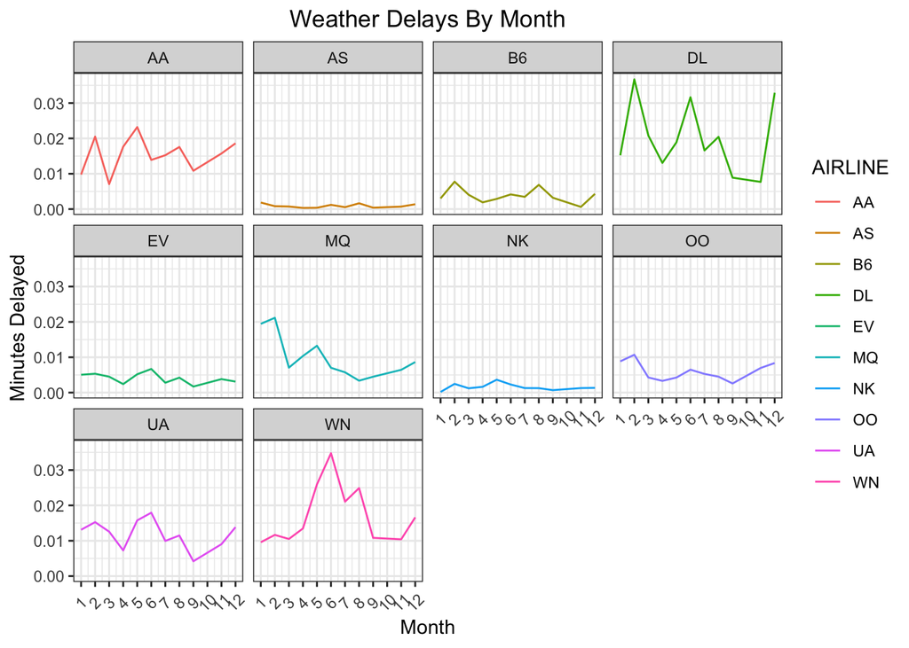

As expected, American Airlines, Jetblue (B6), Delta, American Eagle (MQ), Sky West (OO), United and Southwest have spikes in February and December, months of winter storms. Most of these airlines also have more delays in June through August as well.

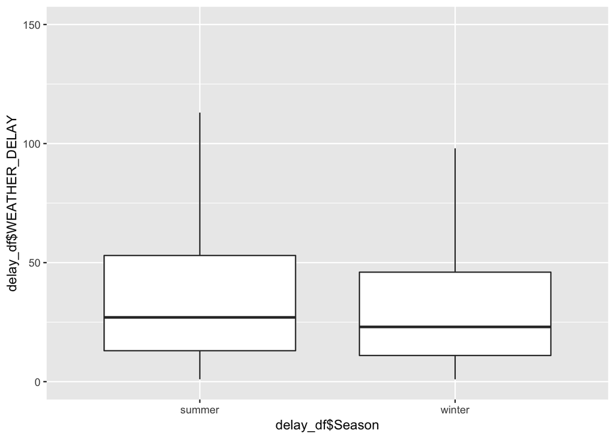

```
##
##  Welch Two Sample t-test
##
## data:  summer_delays$WEATHER_DELAY and nonsummer_delays$WEATHER_DELAY
## t = 1.1453, df = 48179, p-value = 0.2521
## alternative hypothesis: true difference in means is not equal to 0
## 95 percent confidence interval:
##  -0.4782299  1.8228485
## sample estimates:
## mean of x mean of y
##  48.09943  47.42712
```

While there are more delays in summer, there’s no significant difference in the average delay between the summer and non-summer months.